# Example code for GAMM talk at PaPE 2017 stats workshop

Márton Sóskuthy

14/06/2017

## Description

This file is a supplement to a talk that I gave at a satellite workshop on statistical modelling in phonetics at PaPE 2017 in Köln. The code in this file illustrates the structure of the statistical models that I tested for type I error and power. Only a few example models are shown in this file, but the rest of the models covered in the talk are easy to derive from these.

The data set is generated randomly by sourcing an external script, which was used as part of the simulations. The code for the type I / II error simulations as well as the raw data are also available in this GitHub repo, but they are documented separately. Some supporting functions for analysing the results are also provided, though these are not documented in detail.

## Setting things up

Loading the libraries & creating the data set using a separate script.

```r
library(mgcv)
library(itsadug)
```

```r
library(ggplot2)
source("formants/formants_type_2_init.R")
```

For illustration, here’s what the data set looks like:

```r
head(dat)
```

```
##     traj group measurement.no       f2 group.factor group.ordered
## 1 traj_1     A              0 1566.059            A             A
## 2 traj_1     A              1 1563.533            A             A
## 3 traj_1     A              2 1563.024            A             A
## 4 traj_1     A              3 1613.967            A             A
## 5 traj_1     A              4 1945.325            A             A
## 6 traj_1     A              5 2020.768            A             A
##   group.bin start
## 1         0  TRUE
## 2         0 FALSE
## 3         0 FALSE
## 4         0 FALSE
## 5         0 FALSE
## 6         0 FALSE
```

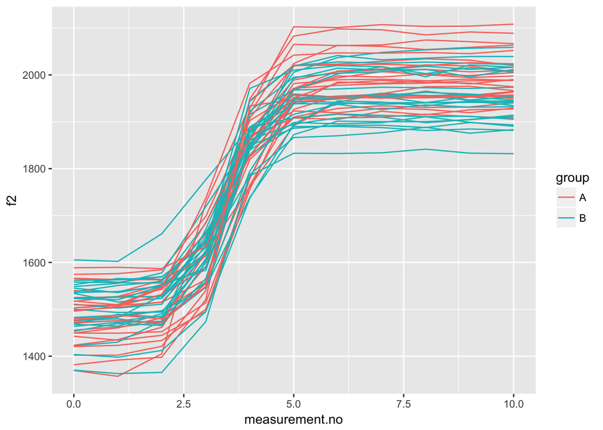

```r
ggplot(dat, aes(x=measurement.no, y=f2, col=group, group=traj)) + geom_line()
```

## Varying model structure, significance testing based on model summary

Here’s a simple GAM without any random structures using a difference smooth to represent the difference between the two groups of trajectories. Note that the data set is already set up so that the grouping variable (group.ordered) is an ordered factor with contrast coding.

```r
mod.noranef <- bam(f2 ~ group.ordered +                        # parametric term
                        s(measurement.no) +                    # reference smooth, bs="tp", k=10
                        s(measurement.no, by=group.ordered),   # difference smooth, bs="tp", k=10
                   data=dat)
summary(mod.noranef)
```

```
##
## Family: gaussian
## Link function: identity
##
## Formula:
## f2 ~ group.ordered + s(measurement.no) + s(measurement.no, by = group.ordered)
##
## Parametric coefficients:
##                Estimate Std. Error t value Pr(>|t|)
## (Intercept)    1807.155      3.419 528.497  < 2e-16 ***
## group.orderedB  -18.244      4.836  -3.773 0.000179 ***
## ---
## Signif. codes:  0 '***' 0.001 '**' 0.01 '*' 0.05 '.' 0.1 ' ' 1
##
## Approximate significance of smooth terms:
##                                    edf Ref.df      F  p-value
## s(measurement.no)                8.537  8.941 545.36  < 2e-16 ***
## s(measurement.no):group.orderedB 1.003  1.007  24.13 1.12e-06 ***
## ---
## Signif. codes:  0 '***' 0.001 '**' 0.01 '*' 0.05 '.' 0.1 ' ' 1
##
## R-sq.(adj) =  0.932   Deviance explained = 93.3%
## fREML = 3007.1  Scale est. = 3215.4    n = 550
```

Here are some further elaborations on this model using different random structures.

```r
# random intercepts by trajectory
mod.rintcpt <- bam(f2 ~ group.ordered +
                        s(measurement.no) +
                        s(measurement.no, by=group.ordered) +
                        s(traj, bs="re"),
                   data=dat)
summary(mod.rintcpt)
```

```
##
## Family: gaussian
## Link function: identity
##
## Formula:
## f2 ~ group.ordered + s(measurement.no) + s(measurement.no, by = group.ordered) +
##     s(traj, bs = "re")
##
## Parametric coefficients:
##                Estimate Std. Error t value Pr(>|t|)
## (Intercept)    1807.155      7.693 234.897   <2e-16 ***
## group.orderedB  -18.244     10.880  -1.677   0.0942 .
## ---
## Signif. codes:  0 '***' 0.001 '**' 0.01 '*' 0.05 '.' 0.1 ' ' 1
##
## Approximate significance of smooth terms:
##                                     edf Ref.df       F  p-value
## s(measurement.no)                 8.712  8.975 843.358  < 2e-16 ***
## s(measurement.no):group.orderedB  1.956  2.438  16.920 9.33e-09 ***
## s(traj)                          42.311 48.000   7.437  < 2e-16 ***
## ---
## Signif. codes:  0 '***' 0.001 '**' 0.01 '*' 0.05 '.' 0.1 ' ' 1
##
## R-sq.(adj) =  0.959   Deviance explained = 96.3%
## fREML = 2921.6  Scale est. = 1929.2    n = 550
```

```r
# random intercepts + slopes by trajectory
mod.rslope <- bam(f2 ~ group.ordered +
                       s(measurement.no) +
                       s(measurement.no, by=group.ordered) +
                       s(traj, bs="re") + s(traj, measurement.no, bs="re"),
                  data=dat)
summary(mod.rslope)
```

```
##
## Family: gaussian
## Link function: identity
##
## Formula:
## f2 ~ group.ordered + s(measurement.no) + s(measurement.no, by = group.ordered) +
##     s(traj, bs = "re") + s(traj, measurement.no, bs = "re")
##
## Parametric coefficients:
##                Estimate Std. Error t value Pr(>|t|)
## (Intercept)     1807.15      14.04 128.692   <2e-16 ***
## group.orderedB   -18.24      19.86  -0.919    0.359
## ---
## Signif. codes:  0 '***' 0.001 '**' 0.01 '*' 0.05 '.' 0.1 ' ' 1
##
## Approximate significance of smooth terms:
##                                     edf Ref.df       F p-value
## s(measurement.no)                 8.858  8.989 494.301 < 2e-16 ***
## s(measurement.no):group.orderedB  3.387  4.196   3.989 0.00284 **
## s(traj)                          43.712 48.000 818.682 < 2e-16 ***
## s(traj,measurement.no)           44.032 48.000 827.219 < 2e-16 ***
## ---
## Signif. codes:  0 '***' 0.001 '**' 0.01 '*' 0.05 '.' 0.1 ' ' 1
##
## R-sq.(adj) =  0.981   Deviance explained = 98.4%
## fREML = 2811.7  Scale est. = 899.42    n = 550
```

```r
# random smooths by trajectory (smooth type set by "xt"; k=10)
# warning about repeated 1-d smooths can be ignored safely
mod.rsmooth <- bam(f2 ~ group.ordered +
                        s(measurement.no) +
                        s(measurement.no, by=group.ordered) +
                        s(measurement.no, traj, bs="fs", m=1, xt="tp", k=10),
                   data=dat)
summary(mod.rsmooth)
```

```
##
## Family: gaussian
## Link function: identity
##
## Formula:
## f2 ~ group.ordered + s(measurement.no) + s(measurement.no, by = group.ordered) +
##     s(measurement.no, traj, bs = "fs", m = 1, xt = "tp", k = 10)
##
## Parametric coefficients:
##                Estimate Std. Error t value Pr(>|t|)
## (Intercept)    1806.343      8.724  207.06   <2e-16 ***
## group.orderedB  -17.796     12.192   -1.46    0.146
## ---
## Signif. codes:  0 '***' 0.001 '**' 0.01 '*' 0.05 '.' 0.1 ' ' 1
##
## Approximate significance of smooth terms:
##                                      edf  Ref.df       F p-value
## s(measurement.no)                  8.922   8.957 364.854  <2e-16 ***
## s(measurement.no):group.orderedB   2.841   3.075   3.052  0.0316 *
## s(measurement.no,traj)           342.600 496.000  13.707  <2e-16 ***
## ---
## Signif. codes:  0 '***' 0.001 '**' 0.01 '*' 0.05 '.' 0.1 ' ' 1
##
## R-sq.(adj) =  0.995   Deviance explained = 99.8%
## fREML = 2722.2  Scale est. = 234.44    n = 550
```

And a version with an autoregressive error model, where the degree of autocorrelation is estimated from a simple version of the model (in this case, mod.noranef). Note that the data set contains a column that indicates the start of each trajectory using the value TRUE (also, points from within the same trajectory are adjacent and ordered according to measurement.no).

```r
# step 1: extracting AR coefficient from mod.noranef
mod.noranef.rho <- start_value_rho(mod.noranef)

# step 2:
mod.AR <- bam(f2 ~ group.ordered +
                   s(measurement.no) +
                   s(measurement.no, by=group.ordered),
              data=dat,
              start.value=dat$start,
              rho=mod.noranef.rho)
summary(mod.AR)
```

```
##
## Family: gaussian
## Link function: identity
##
## Formula:
## f2 ~ group.ordered + s(measurement.no) + s(measurement.no, by = group.ordered)
##
## Parametric coefficients:
##                Estimate Std. Error t value Pr(>|t|)
## (Intercept)    1812.616      9.134 198.449   <2e-16 ***
## group.orderedB  -28.727     12.596  -2.281    0.023 *
## ---
## Signif. codes:  0 '***' 0.001 '**' 0.01 '*' 0.05 '.' 0.1 ' ' 1
##
## Approximate significance of smooth terms:
##                                    edf Ref.df      F  p-value
## s(measurement.no)                8.914  8.998 727.28  < 2e-16 ***
## s(measurement.no):group.orderedB 1.000  1.000  30.71 4.61e-08 ***
## ---
## Signif. codes:  0 '***' 0.001 '**' 0.01 '*' 0.05 '.' 0.1 ' ' 1
##
## R-sq.(adj) =  0.931   Deviance explained = 93.3%
## fREML = 2759.4  Scale est. = 3165.4    n = 550
```

## Other methods of significance testing

Significance testing using model comparison where both the parametric term and the difference smooth are excluded at the same time. Note the use of maximum likelihood (ML) for parameter estimation.

```r
# full model
mod.AR.ML <- bam(f2 ~ group.ordered +
                      s(measurement.no) +
                      s(measurement.no, by=group.ordered),
                 data=dat,
                 start.value=dat$start,
                 rho=mod.noranef.rho,
                 method="ML")
summary(mod.AR.ML)
```

```
##
## Family: gaussian
## Link function: identity
##
## Formula:
## f2 ~ group.ordered + s(measurement.no) + s(measurement.no, by = group.ordered)
##
## Parametric coefficients:
##                Estimate Std. Error t value Pr(>|t|)
## (Intercept)    1812.616      9.134 198.449   <2e-16 ***
## group.orderedB  -28.727     12.596  -2.281    0.023 *
## ---
## Signif. codes:  0 '***' 0.001 '**' 0.01 '*' 0.05 '.' 0.1 ' ' 1
##
## Approximate significance of smooth terms:
##                                    edf Ref.df     F  p-value
## s(measurement.no)                8.914  8.998 727.3  < 2e-16 ***
## s(measurement.no):group.orderedB 1.000  1.001  30.7 4.62e-08 ***
## ---
## Signif. codes:  0 '***' 0.001 '**' 0.01 '*' 0.05 '.' 0.1 ' ' 1
##
## R-sq.(adj) =  0.931   Deviance explained = 93.3%
## -ML = 2771.5  Scale est. = 3165.4    n = 550
```

```r
# nested model
mod.AR.ML.nested <- bam(f2 ~ s(measurement.no),
                        data=dat,
                        start.value=dat$start,
                        rho=mod.noranef.rho,
                        method="ML")

# model comparison

compareML(mod.AR.ML, mod.AR.ML.nested)
```

```
## mod.AR.ML: f2 ~ group.ordered + s(measurement.no) + s(measurement.no, by = group.ordered)
##
## mod.AR.ML.nested: f2 ~ s(measurement.no)
##
## Chi-square test of ML scores
## -----
##              Model    Score Edf  Chisq    Df   p.value Sig.
## 1 mod.AR.ML.nested 2789.006   3
## 2        mod.AR.ML 2771.491   6 17.515 3.000 1.200e-07  ***
```

Visual comparison using confidence intervals around model predictions.

```
## Summary:
##  * group.ordered : factor; set to the value(s): A, B.
##  * measurement.no : numeric predictor; with 30 values ranging from 0.000000 to 10.000000.
##  * traj : factor; set to the value(s): traj_1. (Might be canceled as random effect, check below.)
##  * NOTE : The following random effects columns are canceled: s(measurement.no,traj)
##
```

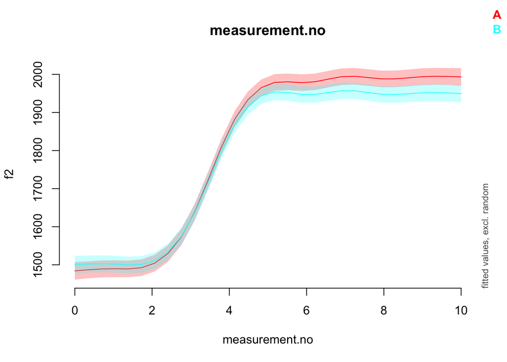

```r
plot_smooth(mod.rsmooth, view="measurement.no", plot_all="group.ordered",
            rm.ranef=T, rug=F)
```

Visual comparison using difference smooth.

```
## Summary:
##  * measurement.no : numeric predictor; with 100 values ranging from 0.000000 to 10.000000.
##  * traj : factor; set to the value(s): traj_1. (Might be canceled as random effect, check below.)
##  * NOTE : The following random effects columns are canceled: s(measurement.no,traj)
##
```

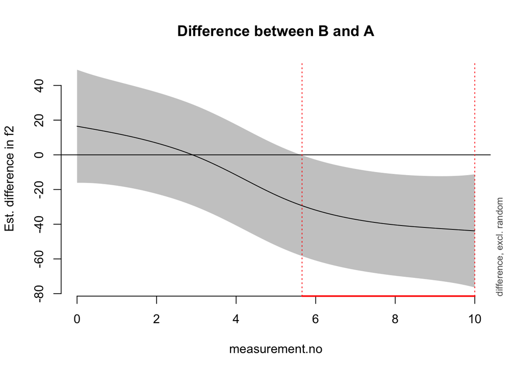

```
##
## measurement.no window(s) of significant difference(s):
##  5.656566 - 10.000000
```

```r
plot_diff(mod.rsmooth, view="measurement.no", comp=list(group.ordered=c("B","A")),
            rm.ranef=T)
```